# Data Cleaning Part 1

Data Wrangling in R

# Data Cleaning

In general, data cleaning is a process of investigating your data for inaccuracies, or recoding it in a way that makes it more manageable.

MOST IMPORTANT RULE - LOOK AT YOUR DATA!

# Read in the UFO dataset

Read in data or download from: http://sisbid.github.io/Data-Wrangling/data/ufo/ufo_data_complete.csv.gz

```r
ufo <- read_delim(
  "https://sisbid.github.io/Data-Wrangling/data/ufo/ufo_data_complete.csv",
  delim = ",")
```

```
Warning: One or more parsing issues, call `problems()` on your data frame for details,
e.g.:
  dat <- vroom(...)
  problems(dat)
```

# The “problems”

You saw warning messages when reading in this dataset. We can see these with the `problems()` function from `readr`.

If we scroll through we can see some interesting notes.

```r
p <-problems(ufo)
p %>% glimpse()
```

```
Rows: 200
Columns: 5
$ row      <int> 878, 1713, 1815, 2858, 3734, 4756, 5389, 5423, 5614, 5849, 60…
$ col      <int> 12, 12, 12, 12, 12, 12, 12, 12, 12, 12, 12, 12, 12, 12, 12, 1…
$ expected <chr> "11 columns", "11 columns", "11 columns", "11 columns", "11 c…
$ actual   <chr> "12 columns", "12 columns", "12 columns", "12 columns", "12 c…
$ file     <chr> "", "", "", "", "", "", "", "", "", "", "", "", "", "", "", "…
```

# Any unique problems?

```r
count(p, expected, actual, col)
```

```
# A tibble: 5 × 4
  expected   actual         col     n
  <chr>      <chr>        <int> <int>
1 11 columns "12 columns"    12   196
2 a double   "0.5`"           6     1
3 a double   "2631600  "      6     1
4 a double   "2`"             6     1
5 a double   "8`"             6     1
```

# The “problems”

```r
colnames(ufo)
```

```
 [1] "datetime"             "city"                 "state"
 [4] "country"              "shape"                "duration (seconds)"
 [7] "duration (hours/min)" "comments"             "date posted"
[10] "latitude"             "longitude"
```

```r
glimpse(ufo)
```

```
Rows: 88,875
Columns: 11
$ datetime               <chr> "10/10/1949 20:30", "10/10/1949 21:00", "10/10/…
$ city                   <chr> "san marcos", "lackland afb", "chester (uk/engl…
$ state                  <chr> "tx", "tx", NA, "tx", "hi", "tn", NA, "ct", "al…
$ country                <chr> "us", NA, "gb", "us", "us", "us", "gb", "us", "…
$ shape                  <chr> "cylinder", "light", "circle", "circle", "light…
$ `duration (seconds)`   <dbl> 2700, 7200, 20, 20, 900, 300, 180, 1200, 180, 1…
$ `duration (hours/min)` <chr> "45 minutes", "1-2 hrs", "20 seconds", "1/2 hou…
$ comments               <chr> "This event took place in early fall around 194…
$ `date posted`          <chr> "4/27/2004", "12/16/2005", "1/21/2008", "1/17/2…
$ latitude               <chr> "29.8830556", "29.38421", "53.2", "28.9783333",…
$ longitude              <chr> "-97.9411111", "-98.581082", "-2.916667", "-96.…
```

# Taking a deeper look

```r
p %>% filter(col != 12)
```

```
# A tibble: 4 × 5
    row   col expected actual      file
  <int> <int> <chr>    <chr>       <chr>
1 30894     6 a double "2`"        ""
2 39616     6 a double "8`"        ""
3 45691     6 a double "2631600  " ""
4 65125     6 a double "0.5`"      ""
```

# Taking a deeper look

The slice function can show us particular row numbers

```r
slice(ufo, 30894 -1) %>% glimpse()
```

```
Rows: 1
Columns: 11
$ datetime               <chr> "2/2/2000 19:33"
$ city                   <chr> "bouse"
$ state                  <chr> "az"
$ country                <chr> "us"
$ shape                  <chr> NA
$ `duration (seconds)`   <dbl> NA
$ `duration (hours/min)` <chr> "each a few seconds"
$ comments               <chr> "Driving through Plomosa Pass towards Bouse Loo…
$ `date posted`          <chr> "2/16/2000"
$ latitude               <chr> "33.9325000"
$ longitude              <chr> "-114.0050000"
```

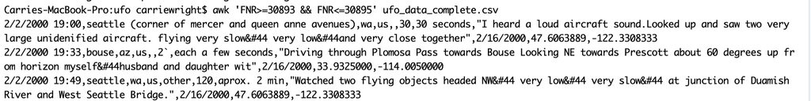

```r
knitr::include_graphics(here::here("images", "raw_ufo_col6.png"))
```

# Reading in again

Now we have a chance to keep but clean these values! We will read in `duration (seconds)` now as a character type. Use `?read_csv` to see documentation about special ways of reading in data.

```r
url <-
  "https://sisbid.github.io/Data-Wrangling/data/ufo/ufo_data_complete.csv"
ufo <-read_csv(url, col_types = cols(`duration (seconds)` = "c"))
```

# Look at the problems again

Looks like an extra column for these rows.

```r
p <- problems(ufo)
count(p, expected, actual, col)
```

```
# A tibble: 1 × 4
  expected   actual       col     n
  <chr>      <chr>      <int> <int>
1 11 columns 12 columns    12   196
```

Our previous problematic rows have values instead of NAs

```r
slice(ufo, 30894 -1) %>% glimpse()
```

```
Rows: 1
Columns: 11
$ datetime               <chr> "2/2/2000 19:33"
$ city                   <chr> "bouse"
$ state                  <chr> "az"
$ country                <chr> "us"
$ shape                  <chr> NA
$ `duration (seconds)`   <chr> "2`"
$ `duration (hours/min)` <chr> "each a few seconds"
$ comments               <chr> "Driving through Plomosa Pass towards Bouse Loo…
$ `date posted`          <chr> "2/16/2000"
$ latitude               <chr> "33.9325000"
$ longitude              <chr> "-114.0050000"
```

# Drop the remaining shifted problematic rows **for now**

Multiply by negative one to drop the rows. Use the `slice` function to “select” those rows based on the index. Need to offset for `-1` because `problems()` gives us the index row based on the raw data, not the read in data (which has a header). We will multiple by negative one to select out those rows as well.

```r
head(p, n = 2)
```

```
# A tibble: 2 × 5
    row   col expected   actual     file
  <int> <int> <chr>      <chr>      <chr>
1   878    12 11 columns 12 columns ""
2  1713    12 11 columns 12 columns ""
```

```r
(pull(p, row) -1) %>% head()
```

```
[1]  877 1712 1814 2857 3733 4755
```

```r
((pull(p, row) -1) *-1) %>% head()
```

```
[1]  -877 -1712 -1814 -2857 -3733 -4755
```

```r
ufo_clean <- ufo %>% slice((pull(p, row)-1)*-1)
```

# Checking

```r
nrow(ufo) - nrow(ufo_clean)
```

```
[1] 196
```

```r
count(p, expected, actual)
```

```
# A tibble: 1 × 3
  expected   actual         n
  <chr>      <chr>      <int>
1 11 columns 12 columns   196
```

# Clean names with the `clean_names()` function from the `janitor` package

```r
colnames(ufo_clean)
```

```
 [1] "datetime"             "city"                 "state"
 [4] "country"              "shape"                "duration (seconds)"
 [7] "duration (hours/min)" "comments"             "date posted"
[10] "latitude"             "longitude"
```

```r
ufo_clean <- clean_names(ufo_clean)
colnames(ufo_clean)
```

```
 [1] "datetime"           "city"               "state"
 [4] "country"            "shape"              "duration_seconds"
 [7] "duration_hours_min" "comments"           "date_posted"
[10] "latitude"           "longitude"
```

# Recoding Variables

# Exact Swaps - recode function

```
within mutate...
recode(variable, value_old = value_new,
           other_value_old = other_value_new)
```

```r
ufo_clean %>%
  mutate(country =
           recode(country, gb = "Great Britain")) %>%
  glimpse()
```

```
Rows: 88,679
Columns: 11
$ datetime           <chr> "10/10/1949 20:30", "10/10/1949 21:00", "10/10/1955…
$ city               <chr> "san marcos", "lackland afb", "chester (uk/england)…
$ state              <chr> "tx", "tx", NA, "tx", "hi", "tn", NA, "ct", "al", "…
$ country            <chr> "us", NA, "Great Britain", "us", "us", "us", "Great…
$ shape              <chr> "cylinder", "light", "circle", "circle", "light", "…
$ duration_seconds   <chr> "2700", "7200", "20", "20", "900", "300", "180", "1…
$ duration_hours_min <chr> "45 minutes", "1-2 hrs", "20 seconds", "1/2 hour", …
$ comments           <chr> "This event took place in early fall around 1949-50…
$ date_posted        <chr> "4/27/2004", "12/16/2005", "1/21/2008", "1/17/2004"…
$ latitude           <chr> "29.8830556", "29.38421", "53.2", "28.9783333", "21…
$ longitude          <chr> "-97.9411111", "-98.581082", "-2.916667", "-96.6458…
```

# Exact Swaps - recode function

```r
ufo_clean %>% mutate(country =
          recode(country,
                 gb = "Great Britain",
                 us = "United States")) %>%
  glimpse()
```

```
Rows: 88,679
Columns: 11
$ datetime           <chr> "10/10/1949 20:30", "10/10/1949 21:00", "10/10/1955…
$ city               <chr> "san marcos", "lackland afb", "chester (uk/england)…
$ state              <chr> "tx", "tx", NA, "tx", "hi", "tn", NA, "ct", "al", "…
$ country            <chr> "United States", NA, "Great Britain", "United State…
$ shape              <chr> "cylinder", "light", "circle", "circle", "light", "…
$ duration_seconds   <chr> "2700", "7200", "20", "20", "900", "300", "180", "1…
$ duration_hours_min <chr> "45 minutes", "1-2 hrs", "20 seconds", "1/2 hour", …
$ comments           <chr> "This event took place in early fall around 1949-50…
$ date_posted        <chr> "4/27/2004", "12/16/2005", "1/21/2008", "1/17/2004"…
$ latitude           <chr> "29.8830556", "29.38421", "53.2", "28.9783333", "21…
$ longitude          <chr> "-97.9411111", "-98.581082", "-2.916667", "-96.6458…
```

# How many countries?

```r
ufo_clean %>% count(country)
```

```
# A tibble: 6 × 2
  country     n
  <chr>   <int>
1 au        593
2 ca       3266
3 de        112
4 gb       2050
5 us      70293
6 <NA>    12365
```

# `case_when()` regions to create a new variable based on conditions of other variables

```
case_when(test ~ value if test is true,
         test2 ~ vlue if test2 is true,
         TRUE ~ value if all above tests are not true) # defaults to NA
```

```r
ufo_clean <- ufo_clean %>% mutate(
            region = case_when(
              country %in% c("us", "ca") ~ "North America",
              country %in% c("de") ~ "Europe",
              country %in% "gb" ~ "Great Britain",
              TRUE ~ "Other"
            ))
ufo_clean %>% select(country, region) %>% head()
```

```
# A tibble: 6 × 2
  country region
  <chr>   <chr>
1 us      North America
2 <NA>    Other
3 gb      Great Britain
4 us      North America
5 us      North America
6 us      North America
```

# `case_when` - another example

The `TRUE` value can also just be the original values.

```r
ufo_clean %>% mutate(country = case_when(
                  country == "gb" ~ "Great Britain",
                  country == "us" ~"United States",
                  country == "au" ~ "Australia",
                  country == "DE" ~ "Germany",
                             TRUE ~ country))%>%
  glimpse()
```

```
Rows: 88,679
Columns: 12
$ datetime           <chr> "10/10/1949 20:30", "10/10/1949 21:00", "10/10/1955…
$ city               <chr> "san marcos", "lackland afb", "chester (uk/england)…
$ state              <chr> "tx", "tx", NA, "tx", "hi", "tn", NA, "ct", "al", "…
$ country            <chr> "United States", NA, "Great Britain", "United State…
$ shape              <chr> "cylinder", "light", "circle", "circle", "light", "…
$ duration_seconds   <chr> "2700", "7200", "20", "20", "900", "300", "180", "1…
$ duration_hours_min <chr> "45 minutes", "1-2 hrs", "20 seconds", "1/2 hour", …
$ comments           <chr> "This event took place in early fall around 1949-50…
$ date_posted        <chr> "4/27/2004", "12/16/2005", "1/21/2008", "1/17/2004"…
$ latitude           <chr> "29.8830556", "29.38421", "53.2", "28.9783333", "21…
$ longitude          <chr> "-97.9411111", "-98.581082", "-2.916667", "-96.6458…
$ region             <chr> "North America", "Other", "Great Britain", "North A…
```

# Summary

- `recode` makes exact swaps
- `case_when` can use conditionals, need to specify what value for if no conditions are met (can be the original value of a variable if we use the variable name).

# Lab

https://sisbid.github.io/Data-Wrangling/labs/data-cleaning-lab.Rmd

# Extra slides

# Strange country values

Sometimes `country` is `NA` even though `state` is known. A conditional more flexible recoding would be helpful…

```r
head(ufo_clean)
```

```
# A tibble: 6 × 12
  datetime         city  state country shape duration_seconds duration_hours_min
  <chr>            <chr> <chr> <chr>   <chr> <chr>            <chr>
1 10/10/1949 20:30 san … tx    us      cyli… 2700             45 minutes
2 10/10/1949 21:00 lack… tx    <NA>    light 7200             1-2 hrs
3 10/10/1955 17:00 ches… <NA>  gb      circ… 20               20 seconds
4 10/10/1956 21:00 edna  tx    us      circ… 20               1/2 hour
5 10/10/1960 20:00 kane… hi    us      light 900              15 minutes
6 10/10/1961 19:00 bris… tn    us      sphe… 300              5 minutes
# ℹ 5 more variables: comments <chr>, date_posted <chr>, latitude <chr>,
#   longitude <chr>, region <chr>
```

# Deeper look

Looking at city… it seems like many of these are in fact in the US.

```r
ufo_clean %>% filter(state == "tx") %>% count(country, state)
```

```
# A tibble: 2 × 3
  country state     n
  <chr>   <chr> <int>
1 us      tx     3742
2 <NA>    tx      299
```

```r
ufo_clean %>% filter(state == "tx" & is.na(country)) %>% select(city)
```

```
# A tibble: 299 × 1
   city
   <chr>
 1 lackland afb
 2 mercedies
 3 texas city/galveston
 4 houston/tomball
 5 bettendorf
 6 dallas/ft. worth (mansfield)
 7 halletsville
 8 gulf of mexico
 9 haltom
10 aubrey/frisco
# ℹ 289 more rows
```

# Checkin Utah as well

```r
ufo_clean %>% filter(state == "ut") %>% count(country, state)
```

```
# A tibble: 2 × 3
  country state     n
  <chr>   <chr> <int>
1 us      ut      659
2 <NA>    ut      138
```

```r
ufo_clean %>% filter(state == "ut" & is.na(country))  %>% select(city)
```

```
# A tibble: 138 × 1
   city
   <chr>
 1 canyonlands np
 2 ogden/clinton
 3 sandy
 4 salt lake valley
 5 sandy
 6 duchenne
 7 west valley
 8 salt flats
 9 west valley
10 west valley
# ℹ 128 more rows
```

# Get US States

```r
ufo_clean %>% filter(country == "us") %>%
  count(state) %>%
  pull(state)
```

```
 [1] "ak" "al" "ar" "az" "ca" "co" "ct" "dc" "de" "fl" "ga" "hi" "ia" "id" "il"
[16] "in" "ks" "ky" "la" "ma" "md" "me" "mi" "mn" "mo" "ms" "mt" "nc" "nd" "ne"
[31] "nh" "nj" "nm" "nv" "ny" "oh" "ok" "or" "pa" "pr" "ri" "sc" "sd" "tn" "tx"
[46] "ut" "va" "vt" "wa" "wi" "wv" "wy"
```

```r
US_states <- ufo_clean %>%
  filter(country == "us") %>%
  count(state) %>%
  pull(state)
```

# Get Canada States

```r
ufo_clean %>% filter(country == "ca") %>%
  count(state) %>%
  pull(state)
```

```
 [1] "ab" "bc" "mb" "nb" "nf" "ns" "nt" "on" "pe" "pq" "qc" "sa" "sk" "yk" "yt"
[16] NA
```

```r
CA_states <- ufo_clean %>%
  filter(country == "ca") %>%
  count(state) %>%
  pull(state)
```

# Get Great Britan states

```r
ufo_clean %>% filter(country == "gb") %>%
  count(state) %>%
  pull(state)
```

```
 [1] "bc" "la" "ms" "nc" "ns" "nt" "ri" "sk" "tn" "wv" "yt" NA
```

```r
GB_states <- ufo_clean %>%
  filter(country == "gb") %>%
  count(state) %>%
  pull(state)
```

A small overlap with US states.

# Get DE states

```r
ufo_clean %>% filter(country == "de") %>%
  count(state) %>%
  pull(state)
```

```
[1] NA
```

# Get AU states

```r
ufo_clean %>% filter(country == "au") %>%
  count(state) %>%
  pull(state)
```

```
[1] "al" "dc" "nt" "oh" "sa" "wa" "yt" NA
```

```r
AU_states <- ufo_clean %>%
  filter(country == "au") %>%
  count(state) %>%
  pull(state)
```

Some overlap with US states.

# Get just unique

The `setdiff()` function can show us what is unique or different for the first of 2 listed sets.

```r
numbers <-c(1,2,3)
letters <-c("a", "b", 3)

setdiff(numbers, letters)
```

```
[1] 1 2
```

```r
setdiff(letters, numbers)
```

```
[1] "a" "b"
```

# Get just unique

```r
US_states
```

```
 [1] "ak" "al" "ar" "az" "ca" "co" "ct" "dc" "de" "fl" "ga" "hi" "ia" "id" "il"
[16] "in" "ks" "ky" "la" "ma" "md" "me" "mi" "mn" "mo" "ms" "mt" "nc" "nd" "ne"
[31] "nh" "nj" "nm" "nv" "ny" "oh" "ok" "or" "pa" "pr" "ri" "sc" "sd" "tn" "tx"
[46] "ut" "va" "vt" "wa" "wi" "wv" "wy"
```

```r
c(AU_states, GB_states, CA_states)
```

```
 [1] "al" "dc" "nt" "oh" "sa" "wa" "yt" NA   "bc" "la" "ms" "nc" "ns" "nt" "ri"
[16] "sk" "tn" "wv" "yt" NA   "ab" "bc" "mb" "nb" "nf" "ns" "nt" "on" "pe" "pq"
[31] "qc" "sa" "sk" "yk" "yt" NA
```

```r
US_states <- setdiff(US_states, c(AU_states, GB_states, CA_states))
US_states
```

```
 [1] "ak" "ar" "az" "ca" "co" "ct" "de" "fl" "ga" "hi" "ia" "id" "il" "in" "ks"
[16] "ky" "ma" "md" "me" "mi" "mn" "mo" "mt" "nd" "ne" "nh" "nj" "nm" "nv" "ny"
[31] "ok" "or" "pa" "pr" "sc" "sd" "tx" "ut" "va" "vt" "wi" "wy"
```

# Continued

```r
AU_states <- setdiff(AU_states, c(US_states, GB_states, CA_states))

CA_states <- setdiff(CA_states, c(US_states, GB_states, AU_states))

GB_states <- setdiff(GB_states, c(US_states, AU_states, CA_states))
```

# How often do rows have a value for country but not a value of “us”?

```r
ufo_clean %>%
  filter(country != "us" & !is.na(country)) %>%
  count(country)
```

```
# A tibble: 4 × 2
  country     n
  <chr>   <int>
1 au        593
2 ca       3266
3 de        112
4 gb       2050
```

# more complicated case_when

Let’s make an assumption that if the state value is within the data as a state for a specific country, than it comes from that country for the sake of illustration.

```r
ufo_clean <- ufo_clean %>% mutate(prob_country =
      case_when((is.na(country) & state %in% c(US_states)) ~ "United States",
                (is.na(country) & state %in% c(CA_states)) ~ "Canada",
                (is.na(country) & state %in% c(AU_states)) ~ "Australia",
                (is.na(country) & state %in% c(GB_states)) ~ "Great Britain",
                   TRUE ~ country))
```

# results

```r
count(ufo_clean, prob_country)
```

```
# A tibble: 10 × 2
   prob_country      n
   <chr>         <int>
 1 Australia       694
 2 Canada          536
 3 Great Britain  5296
 4 United States  5838
 5 au              593
 6 ca             3266
 7 de              112
 8 gb             2050
 9 us            70293
10 <NA>              1
```

# results

Take a look at those NAs.

```r
ufo_clean %>% filter(is.na(prob_country))
```

```
# A tibble: 1 × 13
  datetime         city  state country shape duration_seconds duration_hours_min
  <chr>            <chr> <chr> <chr>   <chr> <chr>            <chr>
1 10/25/1997 22:00 st. … vi    <NA>    light 8                5-8 secds
# ℹ 6 more variables: comments <chr>, date_posted <chr>, latitude <chr>,
#   longitude <chr>, region <chr>, prob_country <chr>
```

# We could confirm with city info and latitude and longitude

```r
ufo_clean %>% filter(country == "de") %>%
  pull(city)
```

```
  [1] "berlin (germany)"
  [2] "berlin (germany)"
  [3] "obernheim (germany)"
  [4] "ottersberg (germany)"
  [5] "urbach (germany)"
  [6] "bremen (30 km south of) (germany)"
  [7] "sembach (germany)"
  [8] "magdeburg (germany)"
  [9] "neuruppin (germany)"
 [10] "lampertheim (germany)"
 [11] "ramstein (germany)"
 [12] "bremen (germany)"
 [13] "nurenburg (germany)"
 [14] "senftenberg (germany)"
 [15] "schwalmtal (germany)"
```

[output cut: 97 more lines]

# Even more specific

```r
ufo_clean <- ufo_clean %>% mutate(prob_country =
      case_when(
      (is.na(country) & state %in% c(US_states))  |
  country == "us" ~ "United States",
      (is.na(country) & state %in% c(CA_states))  |
  country == "ca" ~ "Canada",
      (is.na(country) & state %in% c(AU_states))  |
  country == "au" ~ "Australia",
      (is.na(country) & state %in% c(GB_states))  |
  country == "gb" ~ "Great Britain",
       country == "de" ~ "Germany",
                   TRUE ~ country))
```

We would want to confirm what we recoded with the cities and latitude and longitude, especially to deal with the overlaps in the state lists.

# Check counts

```r
ufo_clean %>%
  count(country, prob_country)
```

```
# A tibble: 10 × 3
   country prob_country      n
   <chr>   <chr>         <int>
 1 au      Australia       593
 2 ca      Canada         3266
 3 de      Germany         112
 4 gb      Great Britain  2050
 5 us      United States 70293
 6 <NA>    Australia       694
 7 <NA>    Canada          536
 8 <NA>    Great Britain  5296
 9 <NA>    United States  5838
10 <NA>    <NA>              1
```